# Laboratorio didattico

The Psychological Burden of the COVID-19

Corrado Caudek

19-05-2022

# Premesse generali

1.Durante lo svolgimento dei vari report, per consentire una migliore comunicazione e fruibilità del materiale da noi prodotto abbiamo usufruito dello strumento GitKraken, ovvero un software che consente di condividere il progetto tra tutti i partecipanti senza l’obbligo di incontrarsi fisicamente.  
2.Abbiamo suddiviso il lavoro fra noi tenendo conto dei punti di forza di ciascuno, in modo da valorizzare più aspetti possibili del progetto

# In cosa consiste la ricerca

Bartusevicius et al. [cit.](https://journals.sagepub.com/doi/full/10.1177/09567976211031847) si sono interessati alle possibili associazioni che possono intercorrere tra il carico psicologico dato dal COVID-19 e i seguenti fenomeni: atteggiamenti anti-sistemici, quali l’insoddisfazione con l’ordine politico e la struttura sociale, attivismo politico pacifico e violenza politica. Conseguentemente, i comportamenti anti-sistemici delineano la variabile dipendente, mentre la variabile indipendente è rappresentata dalla percezione più o meno negativa della situazione pandemica.  
I campioni provengono da adulti residenti in USA, Italia, Danimarca e Ungheria.

# Perché é stata fatta la ricerca

Bartusevicius et al. [cit.](https://journals.sagepub.com/doi/full/10.1177/09567976211031847) si sono posti l’obiettivo di trovare una correlazione tra manifestazioni violente, azioni sovversive e stress dovuti a restrizioni relative al COVID-19 contro gli enti governativi. Altro elemento motivazionale è stato il fatto che, nonostante l’argomento fosse ampiamente discusso, non erano presenti studi validi che esaminassero l’influenza della pandemia su tali comportamenti.

# Metodo

Bartusevicius et al. [cit.](https://journals.sagepub.com/doi/full/10.1177/09567976211031847) hanno raccolto i dati sulle due ondate attraverso sondaggi somministrati online in Paesi con diversi gradi di polarizzazione politica, o animosità nei comportamenti partigiani, e analizzato le conseguenze da COVID-19. Successivamente, i ricercatori si sono posti l’obiettivo di constatare se i risultati potessero essere generalizzati a contesti con diversi gradi di polarizzazione politica.  
È stato fatto uso di una scala valida, ovvero la Need for Chaos Scale [cit.](https://psyarxiv.com/6m4ts/), per misurare le tendenze anti sistemiche; mentre per stimare il “peso” del COVID-19 è stata introdotta la “Perceived COVID-19 Burden Scale”. In entrambe, gli intervistati dovevano indicare il loro grado di accordo in una scala Likert 1-7.

# Risultati

Il bagaglio psicologico del COVID-19 è associato con i comportamenti antisistemici? Si. Difatti, Bartusevicius et al. [cit.](https://journals.sagepub.com/doi/full/10.1177/09567976211031847) hanno individuato un’associazione positiva tra la scala “Perceived COVID-19 burden” e la need for chaos (b = 0.11, 95% intervallo di credibilità [CI] = [0.07, 0.15]). In effetti, analisi successive hanno indicato che le conseguenze da COVID19 percepite erano associate sia con la componente politica (b = 0.15, 95% CI = [0.10, 0.21]) sia con quella non-politica (b = 0.08, 95% CI = [0.04, 0.12]) della scala need for chaos. Quindi, secondo lo studio, tale variazione nella “Perceived COVID-19 burden” è associata con un cambiamento del 6% nella need for chaos.

# Conclusioni

I risultati riportano dati vari e differenti per ogni nazione analizzata. Come inizialmente teorizzato dagli sperimentatori, i dati evidenziano come le conseguenze della pandemia siano state alcune delle cause scatenanti delle manifestazioni e delle rivolte avvenute. Oltre a ciò i dati mostrano che, tra i 4 Paesi analizzati, quelli con restrizioni più ingenti hanno rilevato un incremento del disordine politico. Questo invita a pensare che alcune delle manifestazioni avvenute nei precedenti anni sono state, con molta probabilità, scatenate da questi ultimi fattori di stress causati dalla pandemia.

# Cosa andremo a fare

Il nostro obiettivo è analizzare la differenza di effetto tra il campione americano e quello italiano; ovvero indagare qualora gli italiani abbiano recepito più opprimente la situazione pandemica rispetto agli americani. Per far ciò abbiamo preso come scala di riferimento la “Perceived COVID-19 burden”

Carico i pacchetti necessari

```r
suppressPackageStartupMessages({
  library("tidyverse")
  library("here")
  library("rio")
  library("rstan")
  library("dplyr")
  library("psych")
  library("cmdstanr")
  library("effectsize")
})
```

Lettura dei dati

```r
df <- import(here("DatiR", "hope_violence_final.dta"))
```

Per capire a cosa corrisponda la codifica di `country` conto il numero di casi in ciascun paese e in ciascuna wave.

```r
table(df$wave, df$country)
```

```
##
##        1    2    3    4
##   1 1524 1521 1543 1543
##   2 1151 1286 1241  890
```

Confrontando le frequenze ottenute con i dati riportati dagli autori concludo che la codifica è la seguente:  
- 1: USA;  
- 2: Denmark;  
- 3: Italy;  
- 4: Hungary.

Gli autori riportano che gli item della scala Perceived COVID-19 burden scale (PCBS10) corrispondono alle colonne da Q7_1 a Q7_10. Seleziono queste colonne dal dataframe:

```r
pcbs10_items <- df %>%
   select(
     starts_with("Q7_")
    )
```

Gli autori riportano: The answer options ranged from strongly agree = 0 to strongly disagree = 6.

```r
summary(pcbs10_items)
```

```
##       Q7_1           Q7_2            Q7_3            Q7_4            Q7_5
##  Min.   :1.00   Min.   :1.000   Min.   :1.000   Min.   :1.000   Min.   :1.000
##  1st Qu.:1.00   1st Qu.:3.000   1st Qu.:2.000   1st Qu.:2.000   1st Qu.:3.000
##  Median :2.00   Median :4.000   Median :4.000   Median :3.000   Median :4.000
##  Mean   :2.37   Mean   :4.339   Mean   :3.844   Mean   :3.383   Mean   :4.123
##  3rd Qu.:3.00   3rd Qu.:6.000   3rd Qu.:6.000   3rd Qu.:4.000   3rd Qu.:6.000
##  Max.   :7.00   Max.   :7.000   Max.   :7.000   Max.   :7.000   Max.   :7.000
##       Q7_6            Q7_7            Q7_8            Q7_9           Q7_10
##  Min.   :1.000   Min.   :1.000   Min.   :1.000   Min.   :1.000   Min.   :1.00
##  1st Qu.:2.000   1st Qu.:2.000   1st Qu.:2.000   1st Qu.:2.000   1st Qu.:2.00
##  Median :3.000   Median :3.000   Median :2.000   Median :4.000   Median :4.00
##  Mean   :3.158   Mean   :3.433   Mean   :2.542   Mean   :3.714   Mean   :3.73
##  3rd Qu.:4.000   3rd Qu.:4.000   3rd Qu.:3.000   3rd Qu.:5.000   3rd Qu.:5.00
##  Max.   :7.000   Max.   :7.000   Max.   :7.000   Max.   :7.000   Max.   :7.00
```

Dunque sottraggo 1 per adattare la scala Likert dai parametri 1-7 a 0-6

```r
pcbs10_items_1 <- pcbs10_items - 1
summary(pcbs10_items_1)
```

```
##       Q7_1           Q7_2            Q7_3            Q7_4            Q7_5
##  Min.   :0.00   Min.   :0.000   Min.   :0.000   Min.   :0.000   Min.   :0.000
##  1st Qu.:0.00   1st Qu.:2.000   1st Qu.:1.000   1st Qu.:1.000   1st Qu.:2.000
##  Median :1.00   Median :3.000   Median :3.000   Median :2.000   Median :3.000
##  Mean   :1.37   Mean   :3.339   Mean   :2.844   Mean   :2.383   Mean   :3.123
##  3rd Qu.:2.00   3rd Qu.:5.000   3rd Qu.:5.000   3rd Qu.:3.000   3rd Qu.:5.000
##  Max.   :6.00   Max.   :6.000   Max.   :6.000   Max.   :6.000   Max.   :6.000
##       Q7_6            Q7_7            Q7_8            Q7_9           Q7_10
##  Min.   :0.000   Min.   :0.000   Min.   :0.000   Min.   :0.000   Min.   :0.00
##  1st Qu.:1.000   1st Qu.:1.000   1st Qu.:1.000   1st Qu.:1.000   1st Qu.:1.00
##  Median :2.000   Median :2.000   Median :1.000   Median :3.000   Median :3.00
##  Mean   :2.158   Mean   :2.433   Mean   :1.542   Mean   :2.714   Mean   :2.73
##  3rd Qu.:3.000   3rd Qu.:3.000   3rd Qu.:2.000   3rd Qu.:4.000   3rd Qu.:4.00
##  Max.   :6.000   Max.   :6.000   Max.   :6.000   Max.   :6.000   Max.   :6.00
```

Gli autori affermano:  
Il reverse coding viene applicato agli item 2, 3, 5, 7, 9.  
Il motivo di ciò deriva dal fatto che le domande sono poste in maniera tale che alcune di esse esprimono disaccordo (diminuzione del punteggio), mentre altre l’accordo (aumento del punteggio). Questo però causa imprecisioni poiché le domande appartengono allo stesso concetto (percezione negativa del COVID-19), il che rende le risposte non ben distribuite.  
Quindi per riportarle tutte allo stesso livello viene effettuata l’inversione del valore delle risposte. In questo modo ogni aumento e diminuzione vengono compensati.

```r
keys <- c(1, -1, -1, 1, -1, 1, -1, 1, -1, 1)  #reverse -1 items
pcbs10_items_r <- reverse.code(
  keys,
  pcbs10_items_1,
  mini=rep(0, 10),
  maxi=rep(6, 10)
)
pcbs10_items_1[1:3, ]
```

```
##   Q7_1 Q7_2 Q7_3 Q7_4 Q7_5 Q7_6 Q7_7 Q7_8 Q7_9 Q7_10
## 1    3    3    3    2    3    3    3    2    4     2
## 2    0    1    0    3    3    3    0    0    2     2
## 3    0    3    6    0    5    6    5    0    4     3
```

```r
pcbs10_items_r[1:3, ]
```

```
##   Q7_1 Q7_2- Q7_3- Q7_4 Q7_5- Q7_6 Q7_7- Q7_8 Q7_9- Q7_10
## 1    3     3     3    2     3    3     3    2     2     2
## 2    0     5     6    3     3    3     6    0     4     2
## 3    0     3     0    0     1    6     1    0     2     3
```

Adesso calcolo il punteggio totale:

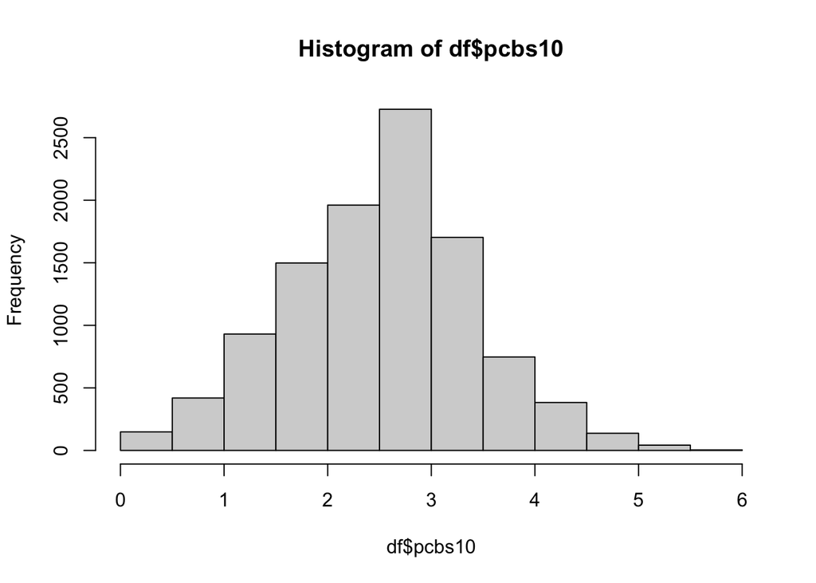

```r
#frequenza relativa
df$pcbs10 <- rowSums(pcbs10_items_r) / 10
hist(df$pcbs10)
```

Seleziono i dati di ciascuna wave:

```r
wave_1 <- df %>%
  filter(wave == 1)

wave_2 <- df %>%
  filter(wave == 2)
#Totale di persone per ondata di tutti i paesi
nrow(wave_1)
```

```
## [1] 6131
```

```r
nrow(wave_2)
```

```
## [1] 4568
```

Estraggo solo le colonne di interesse (id, pcbs10, country)

```r
w1 <- wave_1 %>%
  select(id, pcbs10, country)
w2 <- wave_2 %>%
  select(id, pcbs10, country)
```

Filtriamo i paesi d’interesse (USA e ITA) per le due ondate

```r
#Paese 1: USA
usa1 <- w1 %>%
  filter(country == 1)
usa2 <- w2 %>%
  filter(country == 1)
#Paese 3: ITA
ita1 <- w1 %>%
  filter(country == 3)
ita2 <- w2 %>%
  filter(country == 3)
```

Nel seguente modello abbiamo deciso di prendere in considerazione parametri debolmente informativi per limitare l’influenza eccessiva delle osservazioni estreme (valori anomali) e per facilitare la stima dei parametri mediante MCMC. Quindi, per utilizzare le distribuzioni a priori debolmente informative abbiamo standardizzato i dati. Infine abbiamo riportato i dati su una scala originaria per interpretarli.

Definizione il modello in linguaggio Stan.

```r
model_string <- "
  //definizione dei dati per le funzioni
  data {
  int<lower=0> N;
  vector[N] y;
  vector[N] x;
  real mu_alpha;
  real sigma_alpha;
  real mu_beta;
  real sigma_beta;
  real LOCATION;
  real SCALE;
}
//Standardizzazione dei dati
transformed data {
  vector[N] x_std;
  vector[N] y_std;
  x_std = (x - mean(x)) / sd(x);
  y_std = (y - mean(y)) / sd(y);
}
//Parametri del modello utilizzati per il campionamento
parameters {
  real alpha_std;
  real beta_std;
  real<lower=0> sigma_std;
}
//Modello con cui sono distribuiti i dati
model {
  alpha_std ~ normal(mu_alpha, sigma_alpha);
  beta_std ~ normal(mu_beta, sigma_beta);
  sigma_std ~ cauchy(LOCATION, SCALE);
  y_std ~ normal(alpha_std + beta_std * x_std, sigma_std);
}
// Calcolo valori d’interesse
generated quantities {
  real alpha;
  real beta;
  real<lower=0> sigma;
  real cohen_d;
  alpha = sd(y) * (alpha_std - beta_std * mean(x) / sd(x)) + mean(y);
  beta = beta_std * sd(y) / sd(x);
  sigma = sd(y) * sigma_std;
  cohen_d = beta / sigma;
}
"
```

Salvo il modello Stan in un file.

```r
writeLines(model_string, con = "modello_media.stan")
file <- file.path("modello_media.stan")
```

Compilo il modello.

```r
mod <- cmdstan_model(file)
```

Facciamo il confronto tra due medie indipendenti, ovvero USA e ITA

```r
#Unione dei campioni
y_tot1<-c(usa1$pcbs10, ita1$pcbs10)
y_tot2<-c(usa2$pcbs10, ita2$pcbs10)
#x assume valori dicotomici: x = 0 per gli USA e x =1 per l’ITA
group_tot1 <- c( #variabile dicotomica wave1
  rep(0, length(usa1$pcbs10)),
  rep(1, length(ita1$pcbs10))
  )
group_tot2 <- c( #variabile dicotomica wave 2
  rep(0, length(usa2$pcbs10)),
  rep(1, length(ita2$pcbs10))
  )
#creiamo dataframe con i dati seguenti
d1 <- tibble(y_tot1, group_tot1)
d2 <- tibble(y_tot2, group_tot2)
```

Inserisco i dati in una lista così come richiesto da Stan:

```r
#ondata 1
data_list1 <- list(
  N = length(y_tot1),  #lunghezza vettore y_tot1
  x = d1$group_tot1,  #variabile dicotomica wave1
  y = d1$y_tot1, #dati wave1
  #Prendo dei parametri poco informativi per le distribuzioni
  mu_alpha = 2, #mu media
  sigma_alpha = 2, #sigma deviazione
  mu_beta = 2, #mu media
  sigma_beta = 2, #sigma deviazione
  LOCATION = 0, #parametro della cauchy (dove è centrata la distr.)
  SCALE = 2 #altro parametro della cauchy che ne determina l’altezza
  )

#ondata 2
data_list2 <- list(
  N = length(y_tot2), #lunghezza vettore y_tot2
  x = d2$group_tot2, #variabile dicotomica wave2
  y = d2$y_tot2, #dati wave2
  #Prendo dei parametri poco informativi per le distribuzioni
  mu_alpha = 2, #mu media
  sigma_alpha = 2, #sigma deviazione
  mu_beta = 2, #mu media
  sigma_beta = 2, #sigma deviazione
  LOCATION = 0, #parametro della cauchy (dove è centrata la distr.)
  SCALE = 2 #altro parametro della cauchy che ne determina l’altezza
  )
```

Eseguo il campionamento MCMC.

```r
suppressMessages({
#ondata1
fit1 <- mod$sample(
  data = data_list1,
  iter_sampling = 100000L,  #10k iterazioni
  iter_warmup = 50000L, #5k valori di Burn-in
  chains = 4L, #Esecuzione di 4 catene
  refresh = 0
  )

#ondata2
fit2 <- mod$sample(
  data = data_list2,
  iter_sampling = 100000L, #10k iterazioni
  iter_warmup = 50000L, #5k valori di Burn-in
  chains = 4L, #Esecuzione di 4 catene
  refresh = 0
  )
})
```

```
## Running MCMC with 4 sequential chains...
##
## Chain 1 finished in 41.0 seconds.
## Chain 2 finished in 42.6 seconds.
## Chain 3 finished in 47.3 seconds.
## Chain 4 finished in 43.8 seconds.
##
## All 4 chains finished successfully.
## Mean chain execution time: 43.7 seconds.
## Total execution time: 175.1 seconds.
##
## Running MCMC with 4 sequential chains...
##
## Chain 1 finished in 33.0 seconds.
## Chain 2 finished in 32.4 seconds.
## Chain 3 finished in 30.2 seconds.
## Chain 4 finished in 30.9 seconds.
##
## All 4 chains finished successfully.
## Mean chain execution time: 31.6 seconds.
## Total execution time: 126.8 seconds.
```

Il parametro alfa corrisponde all’intercetta, ovvero il punto in cui la retta incrocia l’asse delle ordinate.

Il cohen permette di definire di quanto differiscono per intensità gli USA e ITA per quanto riguarda una percezione più gravosa della situazione pandemica, ovvero si può concludere che l’ITA ha vissuto maggiormente la pandemia rispetto agli USA. Ciò si deduce anche dal fatto che il risultato (il cohen) non corrisponde allo zero. Difatti, se avesse assunto come valore 0 si sarebbe dedotta una mancanza di effetto. Questa conclusione è osservabile facendo un confronto tra le medie dei paesi osservati per le rispettive ondate.

Prima Wave

```r
fit_stanfit1 <- read_stan_csv(fit1$output_files())
fit1$summary()
```

```
## # A tibble: 8 × 10
##   variable          mean   median     sd    mad       q5      q95  rhat ess_bulk
##   <chr>            <dbl>    <dbl>  <dbl>  <dbl>    <dbl>    <dbl> <dbl>    <dbl>
## 1 lp__      -1482.       -1.48e+3 1.22   0.993  -1.48e+3 -1.48e+3  1.00  207255.
## 2 alpha_std     0.000109  1.04e-4 0.0178 0.0178 -2.91e-2  2.93e-2  1.00  394694.
## 3 beta_std      0.185     1.85e-1 0.0177 0.0177  1.56e-1  2.14e-1  1.00  393845.
## 4 sigma_std     0.983     9.83e-1 0.0126 0.0126  9.63e-1  1.00e+0  1.00  400806.
## 5 alpha         2.55      2.55e+0 0.0205 0.0205  2.51e+0  2.58e+0  1.00  393359.
## 6 beta          0.302     3.01e-1 0.0289 0.0288  2.54e-1  3.49e-1  1.00  393845.
## 7 sigma         0.801     8.01e-1 0.0102 0.0102  7.84e-1  8.18e-1  1.00  400806.
## 8 cohen_d       0.377     3.77e-1 0.0364 0.0364  3.17e-1  4.36e-1  1.00  394807.
## # … with 1 more variable: ess_tail <dbl>
```

Seconda Wave

```r
fit_stanfit2 <- read_stan_csv(fit2$output_files())
fit2$summary()
```

```
## # A tibble: 8 × 10
##   variable          mean   median     sd    mad       q5      q95  rhat ess_bulk
##   <chr>            <dbl>    <dbl>  <dbl>  <dbl>    <dbl>    <dbl> <dbl>    <dbl>
## 1 lp__      -1185.       -1.18e+3 1.23   0.993  -1.19e+3 -1.18e+3  1.00  208474.
## 2 alpha_std     0.000159  1.74e-4 0.0203 0.0203 -3.34e-2  3.36e-2  1.00  417792.
## 3 beta_std      0.106     1.06e-1 0.0204 0.0204  7.22e-2  1.39e-1  1.00  426364.
## 4 sigma_std     0.995     9.95e-1 0.0144 0.0144  9.72e-1  1.02e+0  1.00  428187.
## 5 alpha         2.51      2.51e+0 0.0242 0.0241  2.47e+0  2.55e+0  1.00  424751.
## 6 beta          0.174     1.74e-1 0.0336 0.0336  1.19e-1  2.30e-1  1.00  426364.
## 7 sigma         0.820     8.19e-1 0.0119 0.0119  8.00e-1  8.39e-1  1.00  428187.
## 8 cohen_d       0.213     2.13e-1 0.0411 0.0411  1.45e-1  2.80e-1  1.00  426889.
## # … with 1 more variable: ess_tail <dbl>
```

confronto fra le medie dei paesi  
il paese con la media maggiore ha percepito più duramente il covid-19

```r
mean(usa1$pcbs10)
```

```
## [1] 2.546588
```

```r
mean(ita1$pcbs10)
```

```
## [1] 2.847894
```

```r
mean(ita2$pcbs10)
```

```
## [1] 2.682998
```

```r
mean(usa2$pcbs10)
```

```
## [1] 2.509123
```

Prima Wave

```r
#aggregazione dei dati dei due paesi, con specificazione delle medie
data_means <- aggregate(d1$y_tot1,
                        list(d1$group_tot1),
                        mean)
```

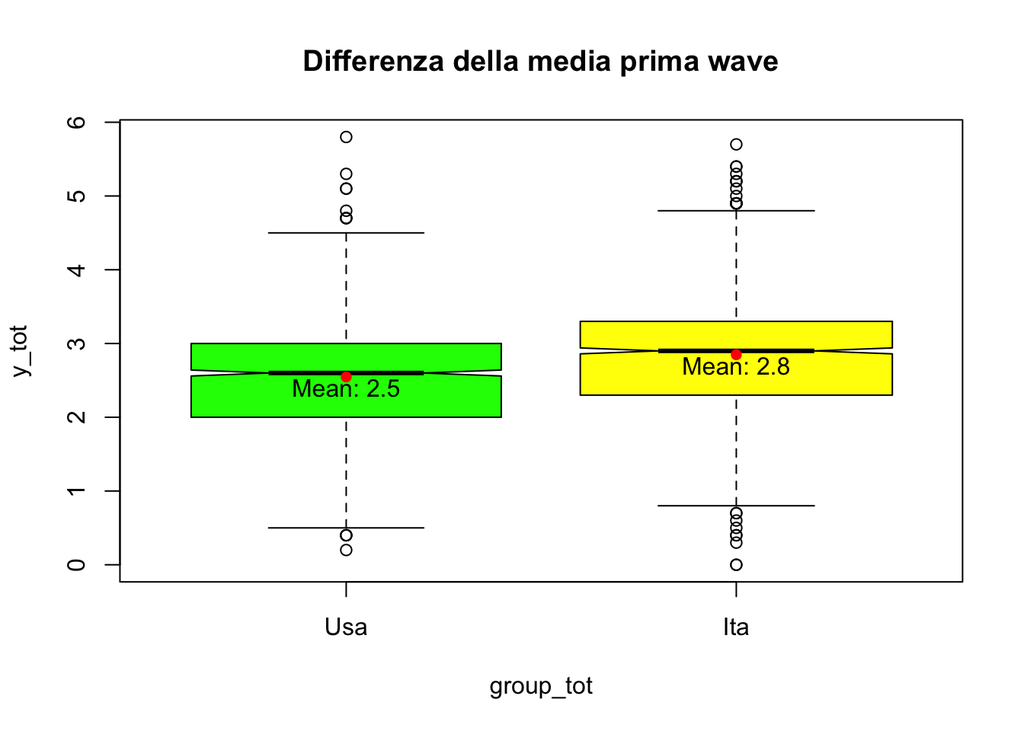

```r
boxplot(d1$y_tot1 ~ d1$group_tot1, #distribuzione di y su x
   xlab = "group_tot", #Etichetta inerente asse x
   ylab = "y_tot",  #Etichetta inerente asse y
   main = "Differenza della media prima wave",
   notch = TRUE, #Notched box plot sono utili per evidenziare una differenza tra le mediane
   varwidth = TRUE, #Disegna un box plot proporzionale alle dimensioni del campione
   col = c("green","yellow"),
   names = c("Usa","Ita")
         )
points(x = 1:nrow(data_means), #Aggiungiamo i punti al boxplot
       y = data_means$x,
       col = "red",
       pch = 16) #Per scegliere i simboli da utilizzare si usa l’opzione pch
text(x = 1:nrow(data_means), #Aggiungiamo il testo al plot
     y = data_means$x - 0.15,
     labels = paste("Mean:", round(data_means$x, 1)), #Inseriamo il valore della media
     col = "black")
```

Seconda Wave

```r
#aggregazione dei dati dei due paesi, con specificazione delle medie
data_means <- aggregate(d2$y_tot2,
                        list(d2$group_tot2),
                        mean)
```

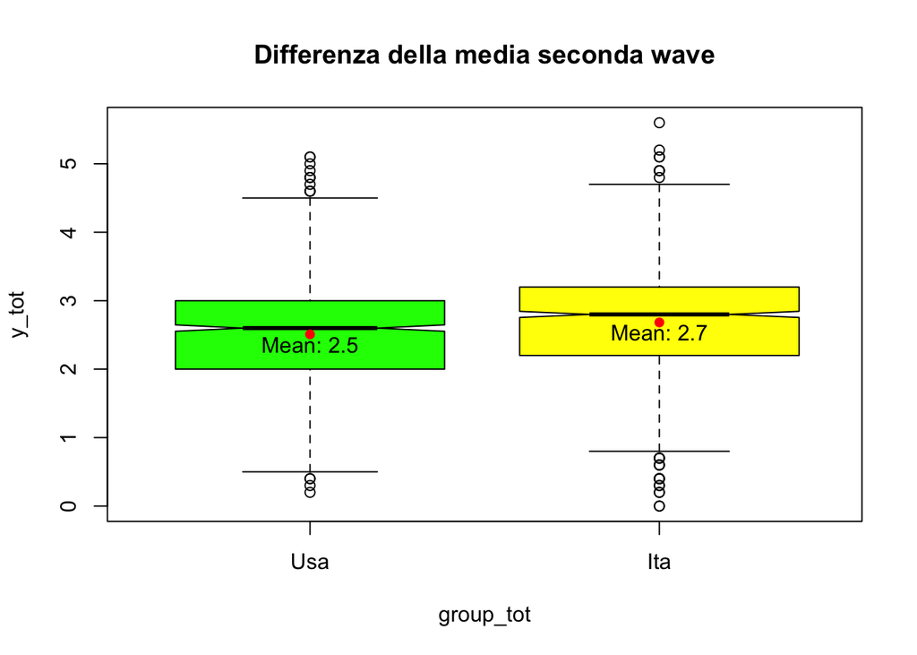

```r
boxplot(d2$y_tot2 ~ d2$group_tot2,  #distribuzione di y su x
   xlab = "group_tot", #Etichetta inerente asse x
   ylab = "y_tot",  #Etichetta inerente asse y
   main = "Differenza della media seconda wave",
   notch = TRUE, #Notched box plot sono utili per evidenziare una differenza tra le mediane
   varwidth = TRUE, #Disegna un box plot proporzionale alle dimensioni del campione
   col = c("green","yellow"),
   names = c("Usa","Ita")
         )
points(x = 1:nrow(data_means), #Aggiungiamo i punti al boxplot
       y = data_means$x,
       col = "red",
       pch = 16) #Per scegliere i simboli da utilizzare si usa l’opzione pch
text(x = 1:nrow(data_means), #Aggiungiamo il testo al plot
     y = data_means$x - 0.15,
     labels = paste("Mean:", round(data_means$x, 1)), #Inseriamo il valore della media
     col = "black")
```

Il progetto è stato svolto da:

- Giulia Viliani
- Virginia Simoncini
- William Tranchino
- Samanta Roncolino
- Leonardo Pecori
- Regina Meister
- Lorenzo Zerauschek
- Alessia Nesti
- Martina Pierallini
- Greta Menichetti
- Elisa Pellegrini
- Chiara Manetti
- Flavia Natoli
- Costanza Lunari
- Marta Mariottini
- Gaia Lenzini
- Matteo Portici
- Camilla Pensalfini
- Lorenza Paladini
- Eleonora Lunardi
- Serena Sooriya
- Isabella Scavone
- Alessia Massini
- Matilde Papini
- Martina Splendorini